# Statistical Relationship and Analysis

Now we are going to use `glm()` function with family Poisson in r to fit this model:

```r
glm.fit <- glm(bikers ~  mnth + hr + workingday + temp + weathersit ,
data = Bikeshare, family=poisson)
summary(glm.fit)
```

```
Call:
glm(formula = bikers ~ mnth + hr + workingday + temp + weathersit,
    family = poisson, data = Bikeshare)

Coefficients:
                           Estimate Std. Error  z value             Pr(>|z|)
(Intercept)                4.118245   0.006021  683.964 < 0.0000000000000002
mnth1                     -0.670170   0.005907 -113.445 < 0.0000000000000002
mnth2                     -0.444124   0.004860  -91.379 < 0.0000000000000002
mnth3                     -0.293733   0.004144  -70.886 < 0.0000000000000002
mnth4                      0.021523   0.003125    6.888   0.0000000000056631
mnth5                      0.240471   0.002916   82.462 < 0.0000000000000002
mnth6                      0.223235   0.003554   62.818 < 0.0000000000000002
mnth7                      0.103617   0.004125   25.121 < 0.0000000000000002
mnth8                      0.151171   0.003662   41.281 < 0.0000000000000002
mnth9                      0.233493   0.003102   75.281 < 0.0000000000000002
mnth10                     0.267573   0.002785   96.091 < 0.0000000000000002
mnth11                     0.150264   0.003180   47.248 < 0.0000000000000002
hr1                       -0.754386   0.007879  -95.744 < 0.0000000000000002
hr2                       -1.225979   0.009953 -123.173 < 0.0000000000000002
hr3                       -1.563147   0.011869 -131.702 < 0.0000000000000002
hr4                       -2.198304   0.016424 -133.846 < 0.0000000000000002
hr5                       -2.830484   0.022538 -125.586 < 0.0000000000000002
hr6                       -1.814657   0.013464 -134.775 < 0.0000000000000002
hr7                       -0.429888   0.006896  -62.341 < 0.0000000000000002
hr8                        0.575181   0.004406  130.544 < 0.0000000000000002
hr9                        1.076927   0.003563  302.220 < 0.0000000000000002
hr10                       0.581769   0.004286  135.727 < 0.0000000000000002
hr11                       0.336852   0.004720   71.372 < 0.0000000000000002
hr12                       0.494121   0.004392  112.494 < 0.0000000000000002
hr13                       0.679642   0.004069  167.040 < 0.0000000000000002
hr14                       0.673565   0.004089  164.722 < 0.0000000000000002
hr15                       0.624910   0.004178  149.570 < 0.0000000000000002
hr16                       0.653763   0.004132  158.205 < 0.0000000000000002
hr17                       0.874301   0.003784  231.040 < 0.0000000000000002
hr18                       1.294635   0.003254  397.848 < 0.0000000000000002
hr19                       1.212281   0.003321  365.084 < 0.0000000000000002
hr20                       0.914022   0.003700  247.065 < 0.0000000000000002
hr21                       0.616201   0.004191  147.045 < 0.0000000000000002
hr22                       0.364181   0.004659   78.173 < 0.0000000000000002
```

[output cut: 42 more lines]

```
workingday                ***
temp                      ***
weathersitcloudy/misty    ***
weathersitlight rain/snow ***
weathersitheavy rain/snow ***
---
Signif. codes:  0 '***' 0.001 '**' 0.01 '*' 0.05 '.' 0.1 ' ' 1

(Dispersion parameter for poisson family taken to be 1)

    Null deviance: 1052921  on 8644  degrees of freedom
Residual deviance:  228041  on 8605  degrees of freedom
AIC: 281159

Number of Fisher Scoring iterations: 5
```

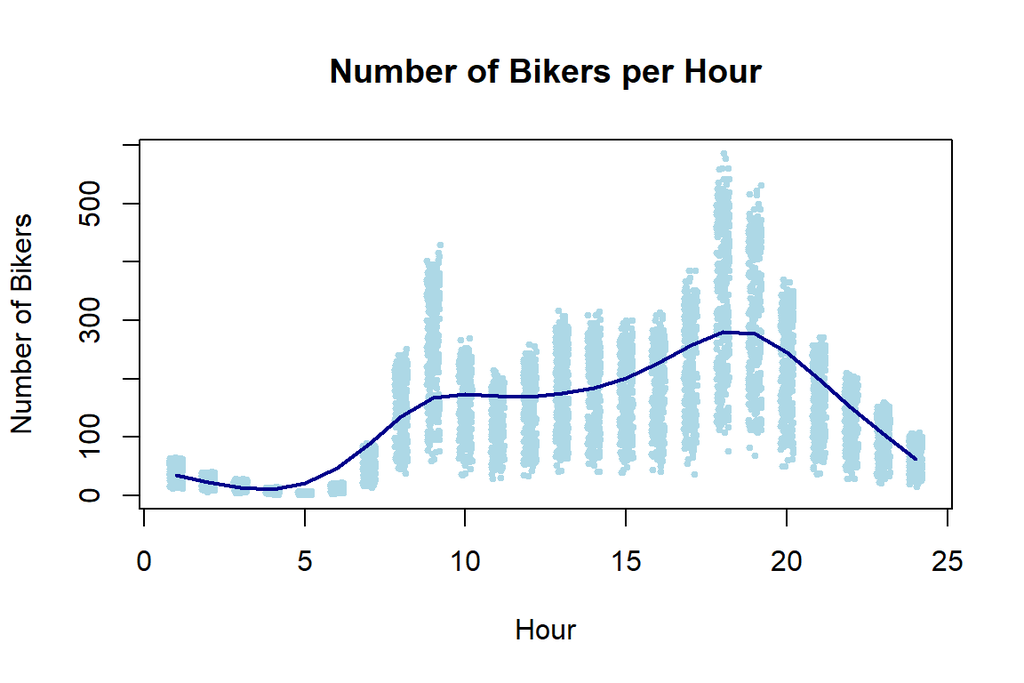

In order to visualize the outputs of the models, we plot the response estimates against the coefficients for both the linear model and the Poisson model. But first, it is important to obtain the coefficient estimates associated with the last month and hour. The coefficients for January through November can be obtained directly from the lm.fit object. The coefficient for December must be explicitly computed as the negative sum of all the other months. The linear model results:

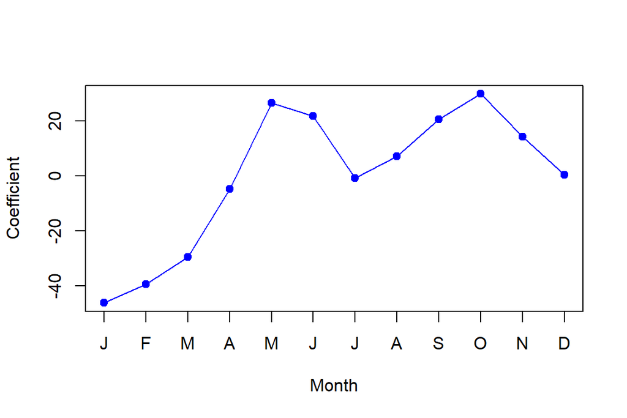

and the glm results:

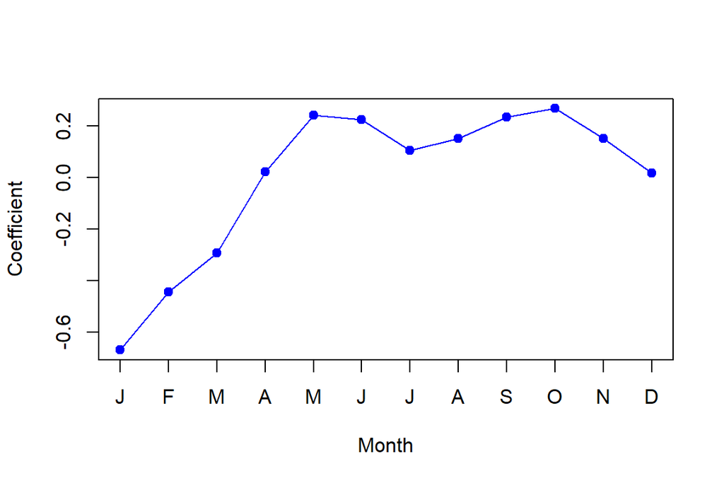

And for the hours using the linear model:

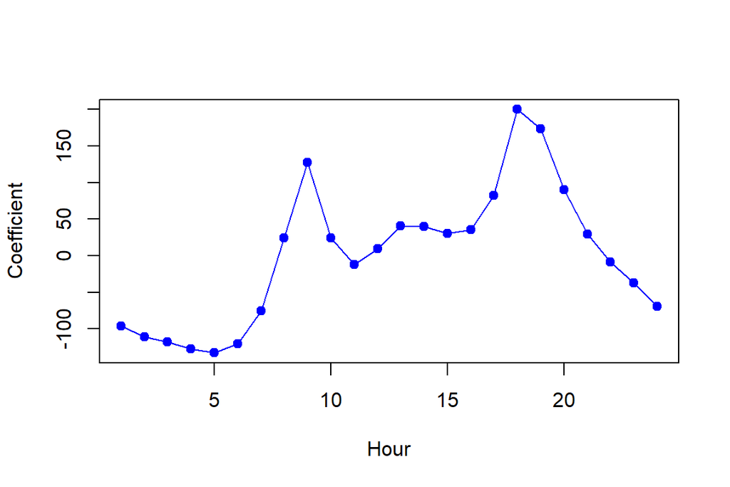

And the glm poisson model:

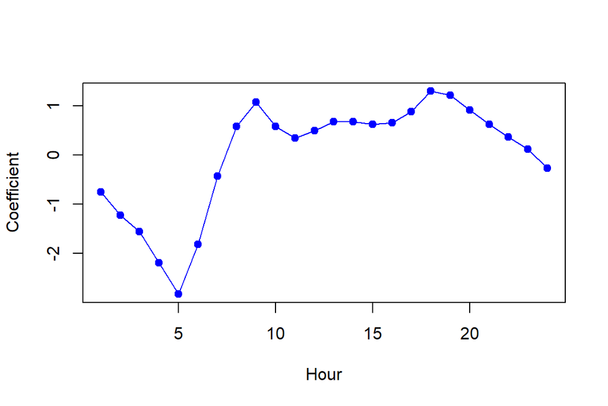

The predictions from the Poisson regression model are correlated with those from the linear model; however, our Poisson model produces non-negative outputs. For Poisson regression the responses at each level of X become more variable with increasing means, where variance=mean.In addition, the mean values of Y at each level of X fall on a curve, not a line. AS a result, at either very low or very high levels of Y, the Poisson regression predictions tend to be larger than those from the linear model.

## 5.3 Simulating data from a Generalized Linear Model

```r
set.seed(1)
x<- rnorm(100)
log.mu<- 0.5+0.3 *x
y <- rpois(100, exp(log.mu))
summary(y)
```

```
   Min. 1st Qu.  Median    Mean 3rd Qu.    Max.
   0.00    1.00    1.00    1.55    2.00    6.00
```

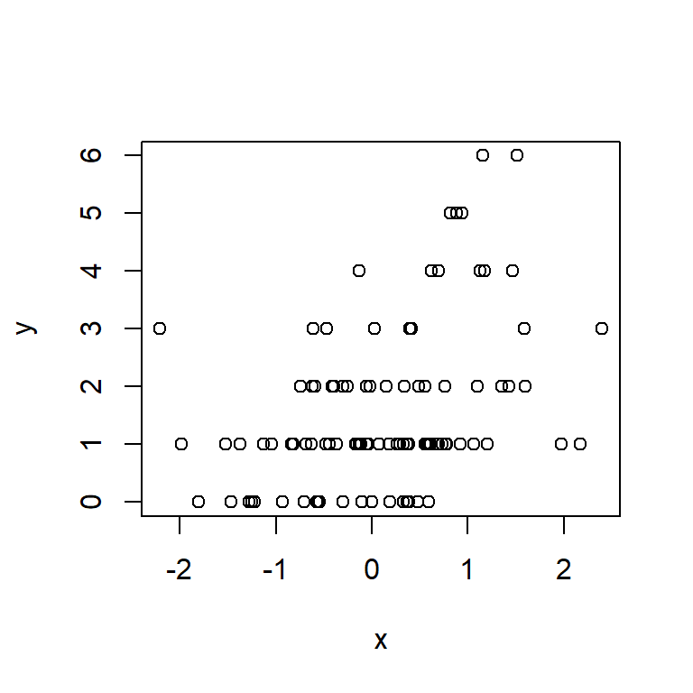

```r
plot(x,y)
```

# 6 Summary

**Linear Regression:** Use When: You want to predict a continuous outcome based on one or more predictor numerical variables. Example: Predicting house prices based on size, location, and age.

**Logistic Regression:** Use When: You want to predict a binary outcome (0/1) based on one or more predictor variables. Example: Predicting whether a customer will buy a product (Yes/No) based on their browsing history.

**Discriminant Analysis (LDA/QDA):** Use When: You want to classify observations into predefined categories based on predictor variables. LDA is used when the assumptions of equal covariance matrices are valid (same variance in each class), while QDA is used when they are not.

Example: Classifying iris species based on sepal and petal measurements.

**Naive Bayes** is useful when the number of parameters is large

**Generalized Linear Models (GLMs)**: Use When: You need more flexibility in modeling different types of outcomes (e.g., counts, binary, proportions) and you might have predictors that are not normally distributed.

Example: Using Poisson regression (a type of GLM) to model the number of calls received by a call center per hour.